# Combining dataframes

## Data

```r
library(tidyverse)
d <- rio::import("data/hta.xlsx", sheet = "data")

demo <- select(d, pid, age, sex) %>% na.omit()

diag <- select(d, pid, starts_with("dx_")) %>% na.omit()

bp <- select(d, pid, contains("bp_v")) %>%
  pivot_longer(sbp_v1:dbp_v6) %>%
  separate(name, into = c("var", "visit")) %>%
  pivot_wider(names_from = var) %>%
  na.omit()

# rows in each dataframe
c("demo" = nrow(demo), "diag" = nrow(diag), "bp" = nrow(bp))
```

```
demo diag   bp
 491  407 1519
```

## Joins

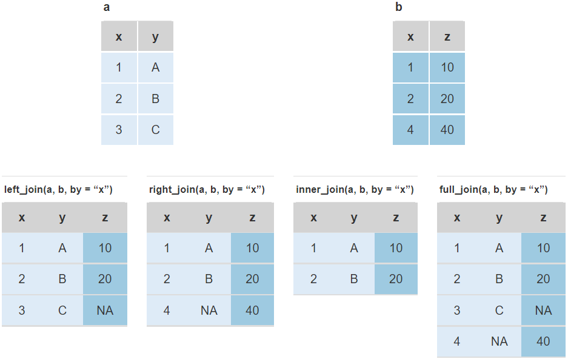

## General syntax

`*_join(data1, data2, by = "keyvar", ...)`

- `left_join(a, b, by ="x")` returns all rows in `a` and matching rows in `b`.
- `right_join(a, b, by ="x")` returns all rows in `b` and matching rows in `a`.
- `inner_join(a, b, by ="x")` returns all matching rows.
- `full_join(a, b, by ="x")` returns all rows in `a` and `b`.

If `by = "keyvar"` is ommitted, rows are matched on all common vars (having the same name in both dataframes), and a message is issued.

## Left join

```r
dd <- left_join(demo, diag, by = "pid")
head(dd)
```

```
  pid age sex dx_dm dx_dyslip dx_lvh
1  11  52   1     2         2      2
2  15  57   2     2         2      2
3  20  62   1     2         2      2
4  24  69   2     2         1      2
5  33  70   2     2         1      2
6  37  64   2     1         2      2
```

```r
nrow(dd)
```

```
[1] 491
```

## Right join

```r
dd <- right_join(demo, diag)
```

```
Joining, by = "pid"
```

```r
head(dd)
```

```
  pid age sex dx_dm dx_dyslip dx_lvh
1  11  52   1     2         2      2
2  15  57   2     2         2      2
3  20  62   1     2         2      2
4  24  69   2     2         1      2
5  33  70   2     2         1      2
6  37  64   2     1         2      2
```

```r
nrow(dd)
```

```
[1] 407
```

## Inner join

```r
dd <- inner_join(demo, diag, by = "pid")
head(dd)
```

```
  pid age sex dx_dm dx_dyslip dx_lvh
1  11  52   1     2         2      2
2  15  57   2     2         2      2
3  20  62   1     2         2      2
4  24  69   2     2         1      2
5  33  70   2     2         1      2
6  37  64   2     1         2      2
```

```r
nrow(dd)
```

```
[1] 403
```

## Full join

```r
dd <- demo %>% full_join(diag, by = "pid")
head(dd)
```

```
  pid age sex dx_dm dx_dyslip dx_lvh
1  11  52   1     2         2      2
2  15  57   2     2         2      2
3  20  62   1     2         2      2
4  24  69   2     2         1      2
5  33  70   2     2         1      2
6  37  64   2     1         2      2
```

```r
nrow(dd)
```

```
[1] 495
```

## More than one row per case

```r
demo %>%
  left_join(bp) %>%
  head()
```

```
  pid age sex visit sbp dbp
1  11  52   1    v1 130  80
2  11  52   1    v2 140  80
3  15  57   2    v1 130  80
4  15  57   2    v2 120  80
5  15  57   2    v3 120  90
6  15  57   2    v4 130  90
```

## Binding rows

`bind_rows(data1, data2, ...)`

```r
d1 <- slice(demo, 1:200)
d2 <- slice(demo, 201:491)

nrow(d1); nrow(d2)               # rows in d1 and d2
```

```
[1] 200
```

```
[1] 291
```

```r
bind_rows(d1, d2) %>% nrow()     # rows in the resulting dataframe
```

```
[1] 491
```

## Exercises

1. Starting from dataframe `bp` (with vars `pid`, `visit`, `sbp`, `dbp`), create new dataframe `bp_monitoring`, with one row per patient and two variables: `pid` and `num_bpm`, the number of visits in which BP was measured.
2. Create a new dataframe `drugs`, with one row per patient and two variables: `pid` and `num_drugs`, the number of drugs a patient has been prescribed.
3. Create dataframe `demo` with variables `pid`, `age`, `sex` and `region`.
4. Combine all three dataframes into a single dataframe having 500 rows.